# Geocomputation with R

Author

Rick Dean

Abstract

Contained here are notes on [3 Attribute data operations](https://geocompr.robinlovelace.net/attr.html) from the book [Geocomputation with R](https://geocompr.robinlovelace.net/index.html) by Lovelace, Nowosad, Muenchow. We will stay close to the book’s major sections with some modifications/additions in the R scripts based on this author’s own preferences.

- Article setup:
  - Install `quarto` executable from <https://quarto.org>
- To compile article inside RStudio:
  - open file `3_Attribute_data_operations.qmd`
  - press `Render` from a recent version of RStudio
- For a table of contents, set the yaml line `toc:` to true and re-render.

# 3 Attribute data operations

Load the Required R Packages.

```r
library(data.table, quietly = T)
library(sf, quietly = T)
library(terra, quietly = T)
library(spData, quietly = T)
library(magrittr, quietly = T)
library(ggplot2, quietly = T)
library(RplotterPkg, quietly = T)
library(RspatialPkg, quietly = T)
```

## 3.1 Introduction

> Attribute data is non-spatial information associated with geographic (geometry) data.

## 3.2 Vector attribute manipulation

> The geometry column of `sf` objects is typically called `geometry` or `geom` but any name can be used.

In the `spData::world` data.frame change the names of the `geom` and `name_long` columns to `g` and `n` respectively using base R data.frame techniques.

Make a copy of `spData::world` and change the copies’ column names:

```r
world_df <- cbind(spData::world)
colnames(world_df)[which(names(world_df) == "geom")] <- "g"
colnames(world_df)[which(names(world_df) == "name_long")] <- "n"
colnames(world_df)
```

```
 [1] "iso_a2"    "n"         "continent" "region_un" "subregion" "type"
 [7] "area_km2"  "pop"       "lifeExp"   "gdpPercap" "g"
```

With the geometry renamed to “g”, set the geometry column of `world_df` and show it and data.frame’s class:

```r
sf::st_geometry(world_df) <- "g"
class(world_df$g)
```

```
[1] "sfc_MULTIPOLYGON" "sfc"
```

```r
class(world_df)
```

```
[1] "sf"         "data.frame"
```

### 3.2.1 Vector attribute subsetting

Select rows of `world_df` for countries with a small area.

Perform the logical filter via `data.table` techniques:

```r
world_small_sf <- data.table::as.data.table(spData::world) %>%
  .[area_km2 < 40000,] %>%
  sf::st_as_sf(.)
```

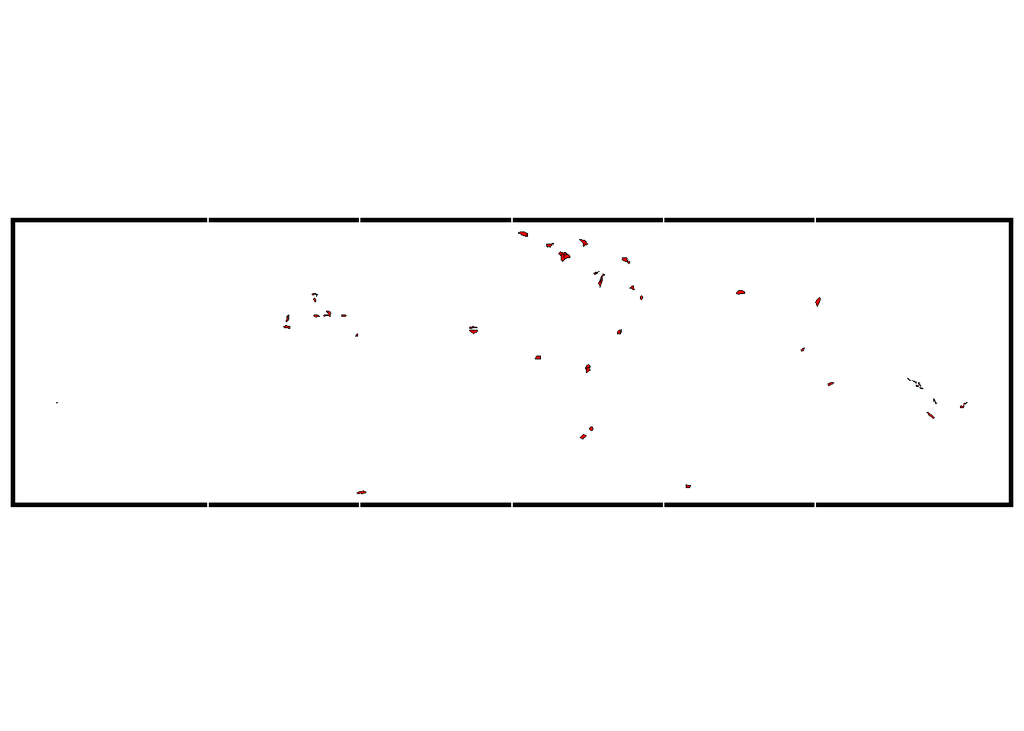

Map of countries whose area is less than 40000 km2.

```r
world_small_plot <- RspatialPkg::get_geom_sf(
    sf = world_small_sf,
    sf_fill = "red",
    hide_x_tics = T,
    hide_y_tics = T
  )
world_small_plot
```

### 3.2.2 Chaining commands with pipes

Use data.table chaining commands to filter, select columns and rows of `spData::world`.

Create the simple feature: Get the first 5 asian countries.

```r
world_asia_sf <- data.table::as.data.table(spData::world) %>%
  .[continent == "Asia"] %>%
  .[1:5, .(name_long, continent, geom)] %>%
  sf::st_as_sf(.)
```

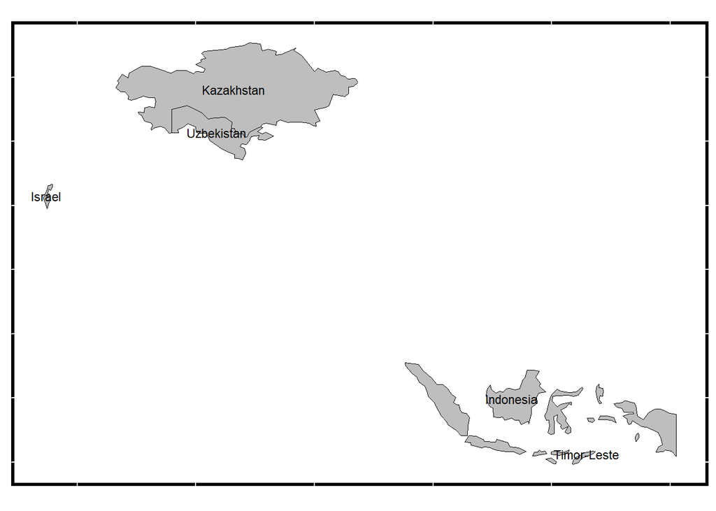

Subset an sf object of countries using data.table selection.

```r
world_asia_plot <- RspatialPkg::get_geom_sf(
  sf = world_asia_sf,
  aes_text = "name_long",
  hide_x_tics = T,
  hide_y_tics = T
)
world_asia_plot
```

### 3.2.3 Vector attribute aggregation

Aggregate the `spData::world` sf object on the “continent” column to give population, area, and number of observations.

Perform the chained aggregation:

```r
world_agg_chain_sf <- data.table::as.data.table(spData::world) %>%
  .[,
    .(Pop = sum(pop, na.rm = TRUE),
      Area = sum(area_km2),
      N = .N,
      Density = round(sum(pop, na.rm = T)/sum(area_km2)),
      geometry = sf::st_union(geom)), by = continent] %>%
  .[order(-N)] %>%
  .[1:6,] %>%
  sf::st_as_sf(.)
```

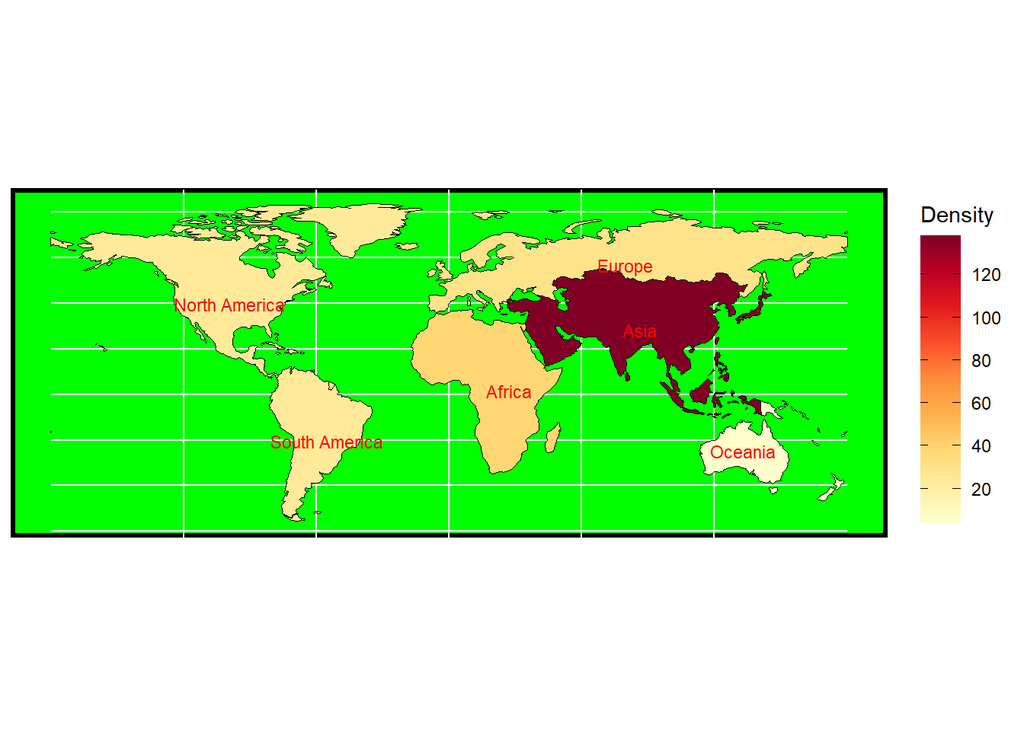

```r
world_agg_chain_plot <- RspatialPkg::get_geom_sf(
    sf = world_agg_chain_sf,
    aes_fill = "Density",
    panel_color = "green",
    hide_x_tics = T,
    hide_y_tics = T,
    legend_key_width = 0.7,
    legend_key_height = 1.0
  ) +
  RspatialPkg::get_geom_sf(
    sf = world_agg_chain_sf,
    aes_text = "continent",
    text_color = "red",
    adding = T
  ) +
ggplot2::scale_fill_gradientn(
  colors = RColorBrewer::brewer.pal(n = 9, name = "YlOrRd"),
  n.breaks = 8
)  +
ggplot2::guides(
  fill = ggplot2::guide_colorbar(
    ticks.colour = "black"
  )
)
world_agg_chain_plot
```

Display the resulting attributes of the sf object in a table:

```r
RplotterPkg::create_table(
  x = as.data.table(world_agg_chain_sf)[,1:5],
  container_width_px = 300
)
```

Summary of country attributes from data.table grouping.

| continent | Pop | Area | N | Density |
| --- | --- | --- | --- | --- |
| Africa | 1154946633 | 29946198 | 51 | 39 |
| Asia | 4311408059 | 31252459 | 47 | 138 |
| Europe | 669036256 | 23065219 | 39 | 29 |
| North America | 565028684 | 24484309 | 18 | 23 |
| South America | 412060811 | 17762592 | 13 | 23 |
| Oceania | 37757833 | 8504489 | 7 | 4 |

### 3.2.4 Vector attribute joining

Using `data.table` techniques join data on coffee production (`spData::coffee_data`) with the `spData::world` dataset with the “name_long” column as the common variable.

```r
coffee_data_dt <- data.table::as.data.table(spData::coffee_data)
world_coffee_sf <- data.table::as.data.table(spData::world) %>%
  coffee_data_dt[., on = c("name_long", "name_long")] %>%
  .[, .(name_long, coffee_production_2017, geom)] %>%
  sf::st_as_sf(.)
world_coffee_sf
```

```
Simple feature collection with 177 features and 2 fields
Geometry type: MULTIPOLYGON
Dimension:     XY
Bounding box:  xmin: -180 ymin: -89.9 xmax: 180 ymax: 83.64513
Geodetic CRS:  WGS 84
First 10 features:
          name_long coffee_production_2017                           geom
1              Fiji                     NA MULTIPOLYGON (((-180 -16.55...
2          Tanzania                     66 MULTIPOLYGON (((33.90371 -0...
3    Western Sahara                     NA MULTIPOLYGON (((-8.66559 27...
4            Canada                     NA MULTIPOLYGON (((-132.71 54....
5     United States                     NA MULTIPOLYGON (((-171.7317 6...
6        Kazakhstan                     NA MULTIPOLYGON (((87.35997 49...
7        Uzbekistan                     NA MULTIPOLYGON (((55.96819 41...
8  Papua New Guinea                     74 MULTIPOLYGON (((141.0002 -2...
9         Indonesia                    360 MULTIPOLYGON (((104.37 -1.0...
10        Argentina                     NA MULTIPOLYGON (((-68.63401 -...
```

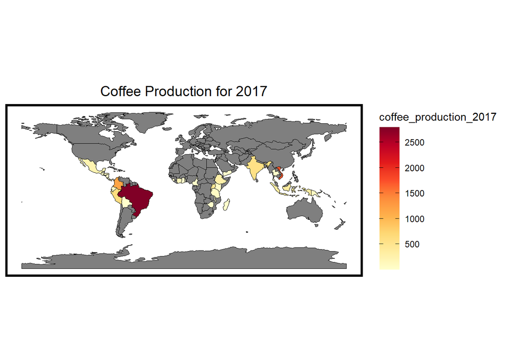

Coffee production around the world.

```r
RspatialPkg::get_geom_sf(
  sf = world_coffee_sf,
  aes_fill = "coffee_production_2017",
  subtitle = "Coffee Production for 2017",
  center_titles = T,
  legend_key_width = 0.7,
  legend_key_height = 1.0
) +
ggplot2::scale_fill_gradientn(
  colors = RColorBrewer::brewer.pal(n = 9, name = "YlOrRd"),
  n.breaks = 8
)  +
ggplot2::guides(
  fill = ggplot2::guide_colorbar(
    ticks.colour = "black"
  )
)
```

### 3.2.5 Creating attributes and removing spatial information

Join the character columns “continent” and “region_un” into one character column called “con_reg” from `spData::world`.

```r
world_join_sf <- data.table::as.data.table(spData::world) %>%
  .[, `:=`(con_reg = paste(continent, region_un, sep = ":"), continent = NULL, region_un = NULL)] %>%
  sf::st_as_sf(.)
head(world_join_sf)
```

```
Simple feature collection with 6 features and 9 fields
Geometry type: MULTIPOLYGON
Dimension:     XY
Bounding box:  xmin: -180 ymin: -18.28799 xmax: 180 ymax: 83.23324
Geodetic CRS:  WGS 84
  iso_a2      name_long        subregion              type    area_km2
1     FJ           Fiji        Melanesia Sovereign country    19289.97
2     TZ       Tanzania   Eastern Africa Sovereign country   932745.79
3     EH Western Sahara  Northern Africa     Indeterminate    96270.60
4     CA         Canada Northern America Sovereign country 10036042.98
5     US  United States Northern America           Country  9510743.74
6     KZ     Kazakhstan     Central Asia Sovereign country  2729810.51
        pop  lifeExp gdpPercap                con_reg
1    885806 69.96000  8222.254        Oceania:Oceania
2  52234869 64.16300  2402.099          Africa:Africa
3        NA       NA        NA          Africa:Africa
4  35535348 81.95305 43079.143 North America:Americas
5 318622525 78.84146 51921.985 North America:Americas
6  17288285 71.62000 23587.338              Asia:Asia
                            geom
1 MULTIPOLYGON (((-180 -16.55...
2 MULTIPOLYGON (((33.90371 -0...
3 MULTIPOLYGON (((-8.66559 27...
4 MULTIPOLYGON (((-132.71 54....
5 MULTIPOLYGON (((-171.7317 6...
6 MULTIPOLYGON (((87.35997 49...
```

Split the character column of `world_join_sf$con_reg` back into separate columns of “continent” and “region_un”.

```r
world_split_sf <- as.data.table(world_join_sf) %>%
  .[, c("continent", "region_un") := tstrsplit(con_reg, ":")] %>%
  sf::st_as_sf(.)
head(world_split_sf)
```

```
Simple feature collection with 6 features and 11 fields
Geometry type: MULTIPOLYGON
Dimension:     XY
Bounding box:  xmin: -180 ymin: -18.28799 xmax: 180 ymax: 83.23324
Geodetic CRS:  WGS 84
  iso_a2      name_long        subregion              type    area_km2
1     FJ           Fiji        Melanesia Sovereign country    19289.97
2     TZ       Tanzania   Eastern Africa Sovereign country   932745.79
3     EH Western Sahara  Northern Africa     Indeterminate    96270.60
4     CA         Canada Northern America Sovereign country 10036042.98
5     US  United States Northern America           Country  9510743.74
6     KZ     Kazakhstan     Central Asia Sovereign country  2729810.51
        pop  lifeExp gdpPercap                con_reg     continent region_un
1    885806 69.96000  8222.254        Oceania:Oceania       Oceania   Oceania
2  52234869 64.16300  2402.099          Africa:Africa        Africa    Africa
3        NA       NA        NA          Africa:Africa        Africa    Africa
4  35535348 81.95305 43079.143 North America:Americas North America  Americas
5 318622525 78.84146 51921.985 North America:Americas North America  Americas
6  17288285 71.62000 23587.338              Asia:Asia          Asia      Asia
                            geom
1 MULTIPOLYGON (((-180 -16.55...
2 MULTIPOLYGON (((33.90371 -0...
3 MULTIPOLYGON (((-8.66559 27...
4 MULTIPOLYGON (((-132.71 54....
5 MULTIPOLYGON (((-171.7317 6...
6 MULTIPOLYGON (((87.35997 49...
```

Rename the “name_long” column of `spData::world` to “name”.

```r
world_rename_sf <- data.table::as.data.table(spData::world) %>%
  data.table::setnames(., old = "name_long", new = "name") %>%
  sf::st_as_sf(.)
colnames(world_rename_sf)
```

```
 [1] "iso_a2"    "name"      "continent" "region_un" "subregion" "type"
 [7] "area_km2"  "pop"       "lifeExp"   "gdpPercap" "geom"
```

## 3.3 Manipulating raster objects

Create from scratch a simple SpatRaster object with 6 rows and columns using `terra::rast()`.

Create the dataset using `terra::rast()`:

```r
elev_scratch_sr <- terra::rast(
  nrows = 6,
  ncols = 6,
  resolution = 0.5,
  xmin = -1.5,
  xmax = 1.5,
  ymin = -1.5,
  ymax = 1.5,
  vals = 1:36,
  names = "scratch"
)
elev_scratch_sr
```

```
class       : SpatRaster
dimensions  : 6, 6, 1  (nrow, ncol, nlyr)
resolution  : 0.5, 0.5  (x, y)
extent      : -1.5, 1.5, -1.5, 1.5  (xmin, xmax, ymin, ymax)
coord. ref. : lon/lat WGS 84
source(s)   : memory
name        : scratch
min value   :       1
max value   :      36
```

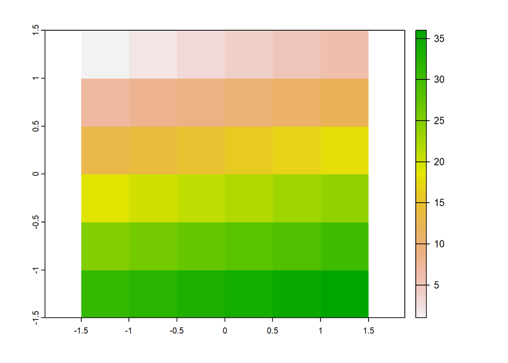

Mapping of a scratch `SpatRaster` created from `terra::rast()`.

```r
terra::plot(elev_scratch_sr)
```

3. Display the SpatRaster object using `RspatialPkg::get_geom_raster()`.

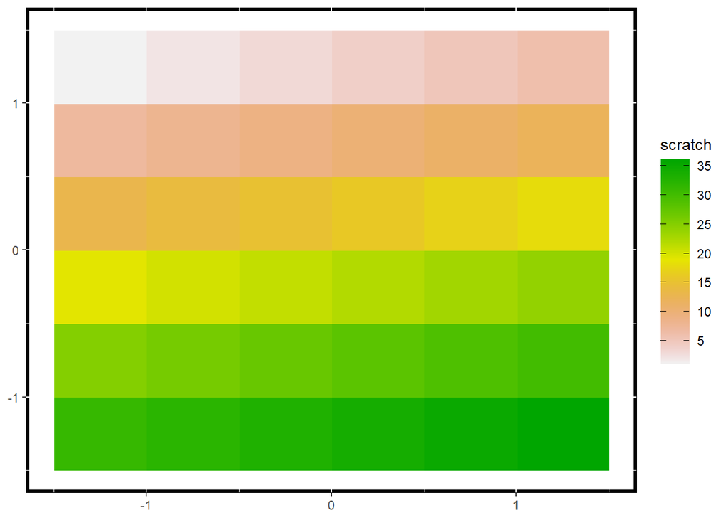

Map a scratch SpatRaster object using`RspatialPkg::get_geom_raster()`.

```r
elev_scratch_df <- as.data.frame(elev_scratch_sr, xy = TRUE)
RspatialPkg::get_geom_raster(
  df = elev_scratch_df,
  aes_x = "x",
  aes_y = "y",
  aes_fill = "scratch",
  legend_key_width = 0.7,
  legend_key_height = 1.0
) +
ggplot2::scale_fill_gradientn(
  colors = rev(grDevices::terrain.colors(50)),
  n.breaks = 8
) +
ggplot2::guides(
  fill = ggplot2::guide_colorbar(
    ticks.colour = "black"
  )
)
```

Create the data.frame:

```r
x <- seq(-1.25, 1.25, length.out = 6)
y <- seq(-1.25, 1.25, length.out = 6)
elev_scratch_df <- expand.grid(x = x, y = y)
elev_scratch_df$z <- 1:36
```

Convert the data.frame to a SpatRaster object:

```r
elev_scratch_df_sr <- terra::rast(elev_scratch_df)
terra::crs(elev_scratch_df_sr) <- "EPSG:4326"
```

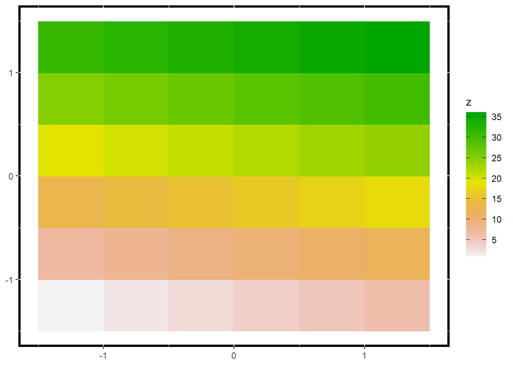

Mapping of a scratch `SpatRaster` created from a data.frame.

```r
elev_scratch_df_df <- as.data.frame(elev_scratch_df_sr, xy = TRUE)
RspatialPkg::get_geom_raster(
  df = elev_scratch_df_df,
  aes_x = "x",
  aes_y = "y",
  aes_fill = "z",
  legend_key_width = 0.7,
  legend_key_height = 1.0
) +
ggplot2::scale_fill_gradientn(
  colors = rev(grDevices::terrain.colors(50)),
  n.breaks = 8
) +
ggplot2::guides(
  fill = ggplot2::guide_colorbar(
    ticks.colour = "black"
  )
)
```

Create a raster object from a factor variable.

Create the factor variable:

```r
grain_order_v <- c("clay","silt","sand")
grain_values_v <- sample(grain_order_v, 36, replace = TRUE)
grain_factor <- factor(grain_values_v, levels = grain_order_v)
```

Create a raster object from the factor:

```r
grain_sr <- terra::rast(
  nrow = 6,
  ncols = 6,
  resolution = 0.5,
  xmin = -1.5,
  xmax = 1.5,
  ymin = -1.5,
  ymax = 1.5,
  vals = grain_factor
)
grain_sr
```

```
class       : SpatRaster
dimensions  : 6, 6, 1  (nrow, ncol, nlyr)
resolution  : 0.5, 0.5  (x, y)
extent      : -1.5, 1.5, -1.5, 1.5  (xmin, xmax, ymin, ymax)
coord. ref. : lon/lat WGS 84
source(s)   : memory
categories  : label
name        : lyr.1
min value   :  clay
max value   :  sand
```

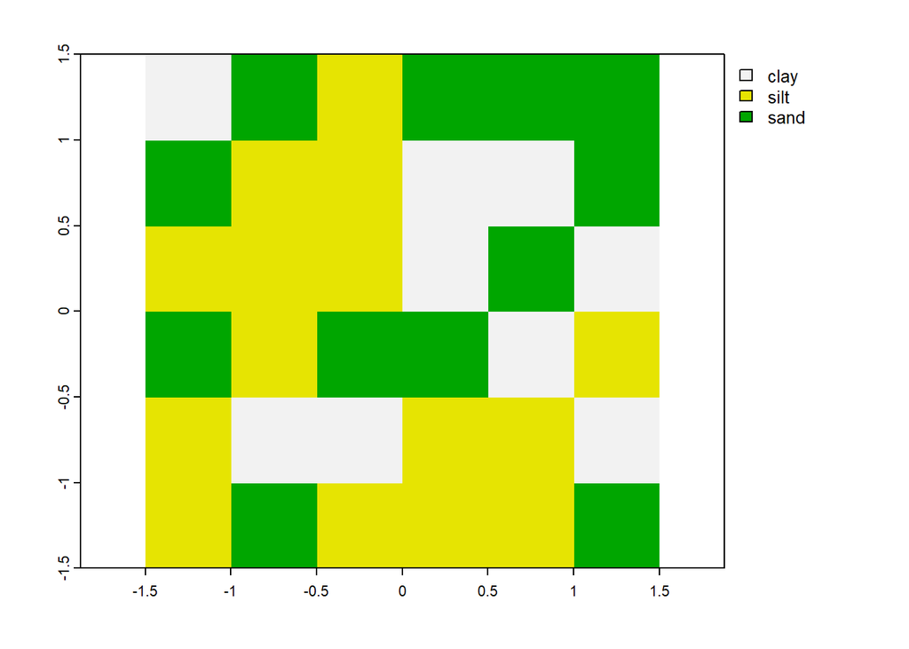

Map of a scratch `SpatRaster` object that is defined from a factor/categorial variable.

```r
terra::plot(grain_sr)
```

### 3.3.1 Raster subsetting

Retrieve the top left pixel in the terra raster object `elev_scratch_sr`.

```r
cell_1_1_df <- elev_scratch_sr[1,1]
cell_1_1_df$scratch
```

```
[1] 1
```

Retrieve the values of all the cells of `grain_sr`.

```r
grain_values_mat <- grain_sr[]
grain_values_mat[,1]
```

```
 [1] 1 3 2 3 3 3 3 2 2 1 1 3 2 2 2 1 3 1 3 2 3 3 1 2 2 1 1 2 2 1 2 3 2 2 2 3
```

### 3.3.2 Summarizing raster objects

Create a frequency table of `grain_sr` by calling `terra::freq()` function.

```r
terra::freq(grain_sr)
```

```
  layer value count
1     1  clay     9
2     1  silt    15
3     1  sand    12
```

### 3.3.3 Conclusion

This concludes the notes on Chapter 3 “Attribute data operations”.